# Dendrogram for similarity across cell types

12 September, 2025

```r
# **MODIFY THIS CHUNK**
project_id  <- "HDMA-public" # determines the name of the cache folder
doc_id      <- "02-global_analysis/02" # determines name of the subfolder of `figures` where pngs/pdfs are saved
out         <- here::here("output/", doc_id); dir.create(out, recursive = TRUE)
figout      <- here::here("figures/", doc_id, "/")
cache       <- paste0("~/scratch/cache/", project_id, "/", doc_id, "/")
```

# 1 Overview

Construct a dendrogram over clusters.

# 2 Set up

```r
# libraries
library(here)
library(dplyr)
library(tidyr)
library(ggplot2)
library(purrr)
library(glue)
library(readr)
library(tibble)
library(stringr)
library(Seurat)
library(cowplot)
library(data.table)
library(pvclust)
library(dendextend)
library(ArchR)
library(here)

# shared project scripts/functions
source(here::here("code/utils/plotting_config.R"))
source(here::here("code/utils/matrix_helpers.R"))
source(here::here("code/utils/seurat_helpers.R"))
source(here::here("code/utils/sj_scRNAseq_helpers.R"))
source(here::here("code/utils/hdma_palettes.R"))

ggplot2::theme_set(theme_BOR())
```

```r
set.seed(100)
```

# 3 Load metadata

Get organ metadata:

```r
organ_meta <- read_tsv(here::here("code/02-global_analysis/01-organs_keep.tsv"))
organ_meta
```

```
## # A tibble: 12 × 3
##    organcode organ            iteration
##    <chr>     <chr>            <chr>
##  1 AG        Adrenal          v4
##  2 BR        Brain            v4
##  3 EY        Eye              v6
##  4 HT        Heart            v4
##  5 LI        Liver            v4
##  6 LU        Lung             v8
##  7 MU        Muscle           v4
##  8 SK        Skin             v4
##  9 SP        Spleen           v4
## 10 ST        StomachEsophagus v2
## 11 TM        Thymus           v4
## 12 TR        Thyroid          v2
```

Set up cluster metadata, which we’ll use to label the dendrogram:

```r
cluster_meta <- map_dfr(list.files(here::here("output/01-preprocessing/02/shared/meta"),
                                   pattern = "*_meta_cluster.txt", full.names = TRUE),
                        ~ fread(.x, data.table = FALSE)) %>%
  mutate(Cluster = glue("{organ_code}_{L1_clusterID}")) %>%
  mutate(Cluster_labelled = glue("{organ_code}_{L1_clusterID}_{L3_clusterName}")) %>%
  left_join(enframe(cmap_organ, "organ", "Color")) %>%
  left_join(enframe(cmap_compartment, "L0_clusterName", "Color_compartment")) %>%
  tibble::column_to_rownames(var = "Cluster")
```

Load cell metadata:

```r
load(here::here("output/02-global_analysis/01/cell_meta_all.Rda"))
```

Load sample metadata:

```r
sample_meta <- read_csv(here::here("output/01-preprocessing/02/shared/SampleMetadata.csv"))
```

# 4 Cluster average expression

To be able to assess some global relationships between all clusters, let’s take average expression across cells in each cluster:

```r
# for each organ, load up the RNA object and calculate cluster mean expression across all genes
for (i in 1:nrow(organ_meta)) {

  print(organ_meta$organ[i])
  seurat_path <- sprintf(here::here("output/01-preprocessing/02/%s/rna_preprocess_output/RNA_obj_clustered_final.rds"), organ_meta$organ[i])

  if (file.exists(seurat_path) & !file.exists(glue("{out}/{organ_meta$organcode[i]}_avg_exp.decontx.Rds"))) {

    obj <- readRDS(seurat_path)

    # prepend clusters with organ code
    obj$Clusters <- paste0(organ_meta$organcode[i], "_", obj$Clusters)
    Idents(obj) <- "Clusters"

    # get average expression for both decontx and RNA assays
    obj_avg <- Seurat::AverageExpression(obj, return.seurat = FALSE, assays = "decontX")$decontX
    saveRDS(obj_avg, glue("{out}/{organ_meta$organcode[i]}_avg_exp.decontx.Rds"))

    # RNA data isn't log-normalized
    DefaultAssay(obj) <- "RNA"
    obj <- NormalizeData(obj)

    obj_avg <- Seurat::AverageExpression(obj, return.seurat = FALSE, assays = "RNA")$RNA
    saveRDS(obj_avg, glue("{out}/{organ_meta$organcode[i]}_avg_exp.rna.Rds"))

  } else {
    next()
  }

}
```

# 5 Dendrogram based on RNA

Here, we can approximately follow a method used by Tasic et al 2018 and Yao et al 2021 in Allen Institute publications, where dendrograms are computed by using the mean cluster expression on top pairwise differentially expressed genes. For construction of the dendrogram, we will consult the `build_dend()` function used in the `scrattch.hicat` package: https://github.com/AllenInstitute/scrattch.hicat/blob/7ccfbc24e3a51326740d08b5b306b18afeb890d9/R/dendro.R#L49

Instead of using pairwise differentially expressed genes, we will use the top cluster markers in the one-vs-all differential expression analyses computed for each organ.

```r
n <- 20
top_markers <- map2(organ_meta$organ, organ_meta$iteration, function(organ, iter) {

  # if data for that organ exists,
  if (!is.na(iter)) {

    # load the markers corresponding to the final iteration
    markers <- fread(
      file.path(here::here("output/01-preprocessing/02/"), organ, glue("rna_preprocess_output/cluster_markers/cluster_markers_SCTdecontXnorm_{iter}.tsv")),
      data.table = FALSE)

    # for each cluster, filter to only positive markers, and select the top 20 based on LFC
    markers %>%
      group_by(cluster) %>%
      filter(avg_log2FC > 0) %>%
      top_n(n, avg_log2FC) %>%
      pull(gene) %>%
      unique()

  }
})

top_markers <- top_markers %>% unlist() %>% unique()
length(top_markers)
```

```
## [1] 1652
```

```r
saveRDS(top_markers, file = glue("{out}/top_markers.Rds"))
```

```r
avg_exp_decontx_list <- map(list.files(out, pattern = "*_avg_exp.decontx.Rds", full.names = TRUE), ~ readRDS(.x))
map(avg_exp_decontx_list, dim)
```

```
## [[1]]
## [1] 25314    10
##
## [[2]]
## [1] 32500    18
##
## [[3]]
## [1] 32067    22
##
## [[4]]
## [1] 32053    16
##
## [[5]]
## [1] 32748    14
##
## [[6]]
## [1] 33472    18
##
## [[7]]
## [1] 32862    22
##
## [[8]]
## [1] 34185    19
##
## [[9]]
## [1] 32513    12
##
## [[10]]
## [1] 33035    22
##
## [[11]]
## [1] 33648    18
##
## [[12]]
## [1] 26163    12
```

```r
# subset each mat to the collection of marker genes, to save time in the merge
avg_exp_decontx_subset_list <- map(avg_exp_decontx_list, ~ .x[rownames(.x) %in% top_markers, ])
map(avg_exp_decontx_subset_list, dim)
```

```
## [[1]]
## [1] 1636   10
##
## [[2]]
## [1] 1652   18
##
## [[3]]
## [1] 1652   22
##
## [[4]]
## [1] 1651   16
##
## [[5]]
## [1] 1652   14
##
## [[6]]
## [1] 1652   18
##
## [[7]]
## [1] 1652   22
##
## [[8]]
## [1] 1652   19
##
## [[9]]
## [1] 1652   12
##
## [[10]]
## [1] 1652   22
##
## [[11]]
## [1] 1652   18
##
## [[12]]
## [1] 1646   12
```

```r
#' A version of base::merge with some handy defaults (bind columns of different
#' matrices, according to their rownames, allowing for differences in the rows
#' present in the two dfs)
#'
#' @param m1 and m2, data frames to merge by rownames
merge2 <- function(m1, m2) {

  # all controls whether or not to keep genes (rows) that apppear in some matrices
  # but not others. We keep them and fill missing values with NA. This is to allow
  # keeping genes that might be highly organ specific.
  merge(m1, m2, by = "row.names", all = TRUE) %>%
    # merge returns a df where the first column contains the rownames, here
    # we just move it out to allow for subsequent merges
    tibble::column_to_rownames("Row.names")

}

# combine all avg exp matrices
avg_exp_decontx_mat_subset <- Reduce(merge2, avg_exp_decontx_subset_list)
dim(avg_exp_decontx_mat_subset)
```

```
## [1] 1652  203
```

```r
any(is.na(avg_exp_decontx_mat_subset))
```

```
## [1] TRUE
```

```r
avg_exp_decontx_mat_subset[is.na(avg_exp_decontx_mat_subset)] <- 0
any(is.na(avg_exp_decontx_mat_subset))
```

```
## [1] FALSE
```

```r
# avg_exp_rna_mat <- Reduce(merge2, avg_exp_rna_list)
# dim(avg_exp_rna_mat)
# any(is.na(avg_exp_rna_mat))

saveRDS(avg_exp_decontx_mat_subset, file = glue("{out}/avg_expr_marker_subset.decontx.Rds"))
```

Dendrogram helpers:

```r
# adapting from scrattch.hicat
# https://github.com/AllenInstitute/scrattch.hicat/blob/7ccfbc24e3a51326740d08b5b306b18afeb890d9/R/dendro.R#L49
pvclust_show_signif_gradient <- function(dend, pvclust_obj, signif_type = c("bp", "au"),
                                         signif_col_fun = NULL, ...) {

  signif_type <- match.arg(signif_type)
  pvalue_per_node <- pvclust_obj$edges[[signif_type]]
  ord <- rank(get_branches_heights(dend, sort = FALSE))
  pvalue_per_node <- pvalue_per_node[ord]
  signif_col <- signif_col_fun(100)
  pvalue_by_all_nodes <- rep(NA, nnodes(dend))
  ss_leaf <- which_leaf(dend)
  pvalue_by_all_nodes[!ss_leaf] <- pvalue_per_node
  pvalue_by_all_nodes <- na_locf(pvalue_by_all_nodes)
  the_cols <- signif_col[round(pvalue_by_all_nodes * 100)]
  signif_lwd = seq(0.5,2,length.out=100)
  the_lwds = signif_lwd[round(pvalue_by_all_nodes * 100)]
  dend = dend %>%
    assign_values_to_branches_edgePar(the_cols, "col") %>%
    assign_values_to_branches_edgePar(the_lwds, "lwd") %>%
    assign_values_to_branches_edgePar(pvalue_by_all_nodes, "conf")
}


#' A distance function for Spearman rank correlation
#' from https://davetang.org/muse/2010/11/26/hierarchical-clustering-with-p-values-using-spearman/
spearman <- function(x, ...) {
  x <- as.matrix(x)
  res <- as.dist(1 - cor(x, method = "spearman", use = "everything"))
  res <- as.dist(res)
  attr(res, "method") <- "spearman"
  return(res)
}


build_dend <- function(mat, n_boot = 100, distance = spearman, hclust = "complete") {

  pvclust_res <- pvclust::pvclust(mat,
                                  nboot = n_boot,
                                  method.dist = distance,
                                  method.hclust = hclust)

  dend <- as.dendrogram(pvclust_res$hclust)
  # dend <- dend %>% pvclust_show_signif_gradient(
  #   pvclust_res,
  #   signif_type = "bp",
  #   signif_col_fun = colorRampPalette(c("gray80", "gray50", "black")))

  return(list(dend = dend, pvclust_res = pvclust_res))

}
```

Construct dendrogram, first for the decontX data:

```r
dim(avg_exp_decontx_mat_subset)

# get correlation matrix
cor_decontx <- cor(avg_exp_decontx_mat_subset, method = "spearman")

# build dendrogram
dend_res_decontx <- build_dend(avg_exp_decontx_mat_subset, distance = spearman, hclust = "average", n_boot = 1000)

save(avg_exp_decontx_mat_subset, cor_decontx, dend_res_decontx,
     file = glue("{out}/dend_res_decontx.Rda"))
```

```r
load(glue("{out}/dend_res_decontx.Rda"))
```

Label and color the leaves:

```r
dend_labeled_decontx <- dend_res_decontx$dend
labels(dend_labeled_decontx) <- cluster_meta[labels(dend_labeled_decontx), "Cluster_labelled"]
labels_colors(dend_labeled_decontx) <- cluster_meta[colnames(cor_decontx), ]$Color[order.dendrogram(dend_labeled_decontx)]

dend_labeled_decontx2 <- dend_res_decontx$dend
labels(dend_labeled_decontx2) <- cluster_meta[labels(dend_labeled_decontx2), "Cluster_labelled"]
labels_colors(dend_labeled_decontx2) <- cluster_meta[colnames(cor_decontx), ]$Color_compartment[order.dendrogram(dend_labeled_decontx2)]
```

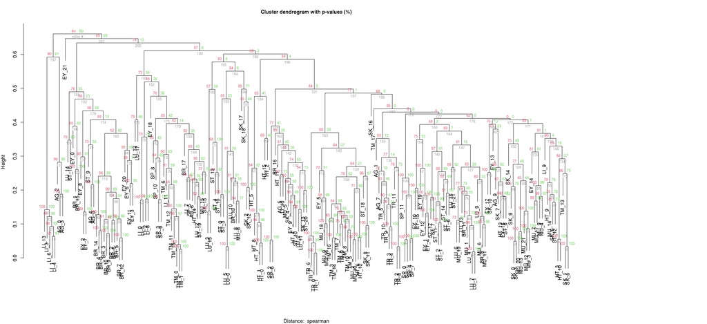

```r
par(mar=c(4,4,4,20))
plot(dend_res_decontx$pvclust_res, horiz = TRUE)
```

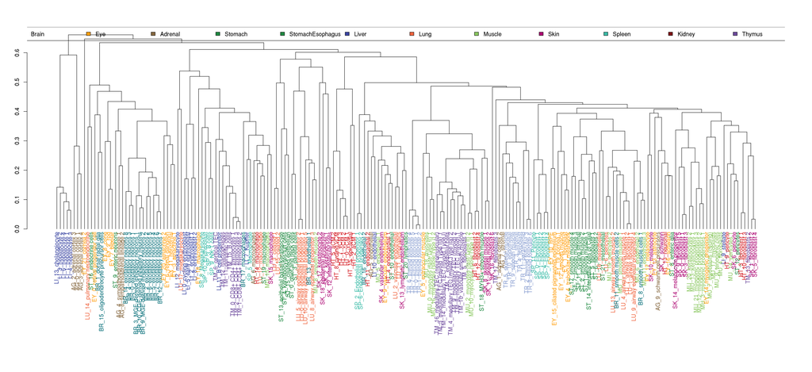

```r
par(mar=c(20,4,4,4))
plot(dend_labeled_decontx, horiz = FALSE)
legend("top", legend = names(cmap_organ), fill = cmap_organ, horiz = TRUE)
```

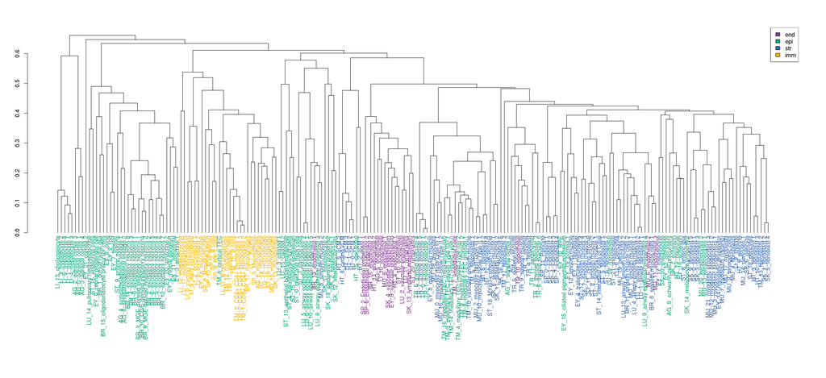

```r
par(mar=c(20,4,4,4))
plot(dend_labeled_decontx2, horiz = FALSE)
legend("topright", legend = names(cmap_compartment), fill = cmap_compartment)
```

Plot the global correlation matrix:

```r
hm_fun <- purrr::partial(pheatmap::pheatmap,
                         mat = cor_decontx[
                           rev(order.dendrogram(dend_labeled_decontx)),
                           rev(order.dendrogram(dend_labeled_decontx))],
                         main = "Correlations; order from bootstrapped tree; mouse only",
                         cluster_rows = FALSE,
                         cluster_cols = FALSE,
                         annotation_col = cluster_meta %>% dplyr::select(organ),
                         annotation_colors = list("organ" = cmap_organ),
                         # use the project's RNA-specific palette
                         color = colorRampPalette(cmap_rna)(n=100),
                         scale = "none",
                         breaks = seq(0, 1, 0.01),
                         border_color = NA,
                         cellwidth = 13,
                         cellheight = 13)

# make png/pdf
hm_fun(filename = glue("{figout}/cor_heatmap.decontx.pdf"))
hm_fun(filename = glue("{figout}/cor_heatmap.decontx.png"))

knitr::include_graphics(glue("{figout}/cor_heatmap.decontx.png"))
```

[figure not shown]

Let’s layer on additional information:

```r
cluster_meta2 <- cluster_meta %>%
  tibble::rownames_to_column("Cluster") %>%
  # get the order from the dendrogram
  left_join(data.frame(Cluster = colnames(cor_decontx)[order.dendrogram(dend_labeled_decontx)]) %>%
              tibble::rowid_to_column("Order"),
            by = "Cluster") %>%
  # order by dendro order
  arrange(Order) %>%
  mutate(Cluster_labelled = factor(Cluster_labelled, levels = unique(.$Cluster_labelled)))

write_tsv(cluster_meta2, glue("{out}/cluster_metadata_dend_order.tsv"))
```

Set up the plot:

```r
# set theme
theme_d <- function()  {

  theme(
    axis.text.y = element_blank(),
    axis.title.y = element_blank(),
    axis.ticks.y = element_blank(),
    axis.text.x = element_text(angle = -90, size = 20, hjust = 0),
    panel.border = element_blank(),
    legend.position = "right", # changed this from bottom to right for proper grid alignment
    legend.text = element_text(angle = 0, hjust = 0, size = 20))

}

p1 <- cell_meta_rna %>%
  left_join(cluster_meta2 %>% dplyr::select(Cluster, Cluster_labelled), by = "Cluster") %>%
  ggplot(aes(x = Cluster_labelled)) +
  geom_bar(aes(fill = PCW), position = "fill") +
  scale_fill_manual(values = cmap_pcw) +
  theme_d() +
  coord_flip() +
  ggtitle("PCW")

p2 <- cluster_meta2 %>%
  ggplot(aes(x = Cluster_labelled, y = median_numi)) +
  geom_col(aes(fill = median_numi)) +
  # geom_raster(aes(fill = median_numi)) +
  scale_fill_gradientn(colors = ylrd) +
  theme_d() +
  coord_flip() +
  ggtitle("median UMIs/cell") +
  ylab(NULL)

p3 <- cluster_meta2 %>%
  ggplot(aes(x = Cluster_labelled, y = median_ngene)) +
  geom_col(aes(fill = median_ngene)) +
  # geom_raster(aes(fill = median_ngene)) +
  scale_fill_gradientn(colors = ylrd) +
  theme_d() +
  coord_flip() +
  ggtitle("median # genes/cell") +
  ylab(NULL)

p4 <- cluster_meta2 %>%
  ggplot(aes(x = Cluster_labelled, y = median_nfrags)) +
  geom_col(aes(fill = median_nfrags)) +
  # geom_raster(aes(fill = median_nfrags)) +
  scale_fill_gradientn(colors = ylrd) +
  theme_d() +
  coord_flip() +
  ggtitle("median \n# fragments/cell") +
  ylab(NULL)

p5 <- cluster_meta2 %>%
  ggplot(aes(x = Cluster_labelled, y = median_tss)) +
  geom_col(aes(fill = median_tss)) +
  # geom_raster(aes(fill = median_tss)) +
  scale_fill_gradientn(colors = ylrd) +
  theme_d() +
  coord_flip() +
  ggtitle("median \nTSS enrichment") +
  ylab(NULL)

p6 <- cluster_meta2 %>%
  ggplot(aes(x = Cluster_labelled, y = 1)) +
  geom_col(aes(fill = L0_clusterName)) +
  scale_fill_manual(values = cmap_compartment) +
  theme_d() +
  coord_flip() +
  ggtitle("Compartment") +
  ylab(NULL)

p7 <- cluster_meta2 %>%
  ggplot(aes(x = Cluster_labelled, y = 1)) +
  geom_col(aes(fill = organ)) +
  scale_fill_manual(values = cmap_organ) +
  theme_d() + theme(legend.position = "none") +
  coord_flip() +
  ggtitle("Organ") +
  ylab(NULL)

meta_withbioid <- cell_meta_rna %>%
  left_join(cluster_meta2 %>% dplyr::select(Cluster, Cluster_labelled), by = "Cluster") %>%
  left_join(sample_meta %>% dplyr::select(Sample=SampleName, BioID))
meta_withbioid$BioID <- as.factor(meta_withbioid$BioID)

pal <- colorRampPalette(c("lightgray", "orange", "brown"))(23)

p8 <- meta_withbioid %>%
  ggplot(aes(x = Cluster_labelled)) +
  geom_bar(aes(fill = BioID), position = "fill") +
  scale_fill_manual(values=pal) +
  theme_d() +
  coord_flip() +
  ggtitle("BioID")

# we have orders of magnitudes different # of cells in some clusters,
# so let's put these on a log10 scale
p0 <- cluster_meta2 %>%
  ggplot(aes(x = Cluster_labelled, y = log10(ncell))) +
  geom_col(aes(fill = organ)) +
  scale_x_discrete(position = "top") +
  scale_fill_manual(values = cmap_organ) +
  theme(panel.border = element_blank(), legend.position = "right") +
  coord_flip() +
  ggtitle("# cells")


plot_grid(p1, p8, p2, p3, p4, p5, p6, p7, p0, nrow = 1,
          rel_widths = c(0.1, 0.1, 0.1, 0.1, 0.1, 0.1, 0.1, 0.1, 0.2),
          align = "h", axis = "tb")
```

[figure not shown]

# 6 Visualize the top marker heatmap

```r
# scale
avg_exp_decontx_mat_subset_scaled <- avg_exp_decontx_mat_subset %>%
  # genes are in rows; for each gene, scale expression to [0, 1]
  apply(1, scales::rescale) %>%
  t()
```

Loop through clusters *in dendrogram order* to get their top marker genes, to try and get a diagonal heatmap:

```r
# get an order for marker genes based on the dendrogram order. First we will simply
# load the markers, as before, but without getting unique genes, and keeping
# cluster from which each marker originated
n <- 20
top_markers_df <- map2_dfr(organ_meta$organ, organ_meta$iteration, function(organ, iter) {

  # if data for that organ exists,
  if (!is.na(iter)) {

    # load the markers corresponding to the final iteration
    markers <- fread(
      file.path(here::here("output/01-preprocessing/02/"), organ, glue("rna_preprocess_output/cluster_markers/cluster_markers_SCTdecontXnorm_{iter}.tsv")),
      data.table = FALSE)

    # for each cluster, filter to only positive markers, and select the top 20 based on LFC
    markers %>%
      group_by(cluster) %>%
      filter(avg_log2FC > 0) %>%
      top_n(n, avg_log2FC) %>%
      tibble::add_column(organ = organ, .before = 1)

  }
})

head(top_markers_df)
```

```
## # A tibble: 6 × 8
## # Groups:   cluster [1]
##   organ       p_val avg_log2FC pct.1 pct.2 p_val_adj cluster gene
##   <chr>       <dbl>      <dbl> <dbl> <dbl>     <dbl>   <int> <chr>
## 1 Adrenal 0               2.86 0.998 0.55  0               0 NPC1
## 2 Adrenal 0               2.46 0.904 0.152 0               0 C1orf54
## 3 Adrenal 0               2.31 0.99  0.508 0               0 GALC
## 4 Adrenal 0               2.26 0.989 0.271 0               0 USP36
## 5 Adrenal 0               2.05 1     0.689 0               0 GRK5
## 6 Adrenal 5.54e-305       1.91 1     0.664 1.40e-300       0 CDK8
```

```r
# reformat df
top_markers_df <- top_markers_df %>%
  left_join(cluster_meta2, by = c("organ" = "organ", "cluster" = "L1_clusterID")) %>%
  dplyr::select(-cluster)
# arrange by Order, then pull out markers
markers_ordered_unique <- top_markers_df %>% arrange(Order) %>% group_by(Cluster) %>% pull(gene) %>% unique()
length(markers_ordered_unique)
```

```
## [1] 1652
```

```r
all(is.numeric(avg_exp_decontx_mat_subset_scaled[markers_ordered_unique, cluster_meta2$Cluster]))
```

```
## [1] TRUE
```

```r
cluster_meta2 <- as.data.frame(cluster_meta2)
rownames(cluster_meta2) <- cluster_meta2$Cluster

# make a function to plot the heatmap in dendrogram order, and with markers ordered diagonally
marker_hm_fun <- purrr::partial(
  pheatmap::pheatmap,
  mat = avg_exp_decontx_mat_subset_scaled[markers_ordered_unique, cluster_meta2$Cluster],
  border_color = NA,
  cluster_cols = FALSE,
  cluster_rows = FALSE,
  annotation_col = cluster_meta2 %>% dplyr::select(organ),
  annotation_colors = list("organ" = cmap_organ),
  # use the project's RNA-specific palette
  color = colorRampPalette(cmap_rna)(n=100),
  show_rownames = TRUE,
  cellwidth = 13,
  cellheight = 5,
  main = "Average expression of top 20 marker genes per cluster, scaled to [0,1] across clusters")

# make png/pdf
marker_hm_fun(filename=paste0(figout, "/marker_heatmap.decontx.pdf"))
# marker_hm_fun(filename = glue("{figout}/marker_heatmap.decontx.png"))
#
# knitr::include_graphics(glue("{figout}/marker_heatmap.decontx.png"))
```

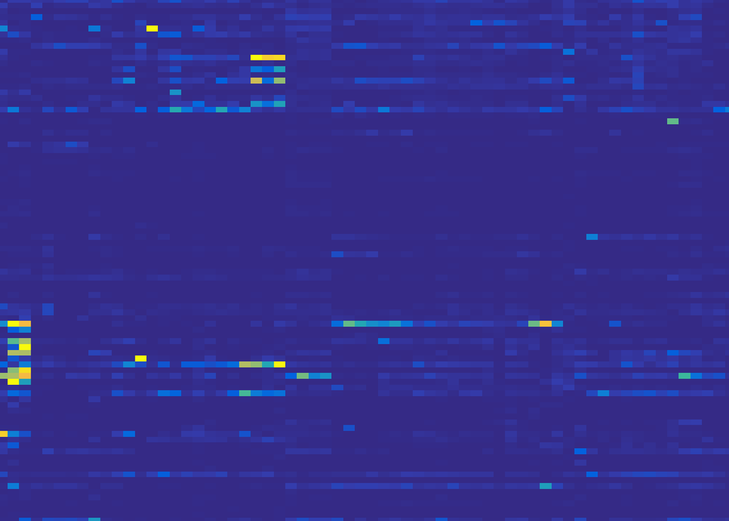

```r
pheatmap::pheatmap(
  mat = avg_exp_decontx_mat_subset_scaled[markers_ordered_unique, cluster_meta2$Cluster],
  border_color = NA,
  cluster_cols = FALSE,
  cluster_rows = FALSE,
  # annotation_col = cluster_meta2 %>% dplyr::select(organ),
  # annotation_colors = list("organ" = cmap_organ),
  # use the project's RNA-specific palette
  color = colorRampPalette(cmap_rna)(n=100),
  show_rownames = TRUE,
  cellwidth = 8,
  cellheight = 4,
  main = "Average expression of top 20 marker genes per cluster, scaled to [0,1] across clusters")
```

### manual selection of marker genes inspect the marker genes in a few cell groups of interest

```r
top_markers_df[grep("hepatocyte", top_markers_df$L3_clusterName),"gene"] %>%
    table %>% as.data.frame %>% dplyr::arrange(desc(Freq))
```

```
##                  . Freq
## 1              A2M    2
## 2             AHSG    2
## 3           AKR1C1    2
## 4               C3    2
## 5               C5    2
## 6           CYP3A5    2
## 7              FGA    2
## 8              FGB    2
## 9              FGG    2
## 10           ITIH1    2
## 11        MIR122HG    2
## 12          PTP4A1    2
## 13          SLC2A2    2
## 14        SLC39A14    2
```

[output cut: 51 more lines]

```r
top_markers_df[grep("endothelial", top_markers_df$L3_clusterName),"gene"] %>%
    table %>% as.data.frame %>% dplyr::arrange(desc(Freq))
```

```
##                   . Freq
## 1              FLT1    7
## 2             PTPRB    7
## 3             MECOM    6
## 4            ADGRL4    5
## 5            CALCRL    5
## 6               KDR    5
## 7              LDB2    5
## 8            PECAM1    5
## 9              ANO2    4
## 10         ARHGAP29    4
## 11            DACH1    4
## 12             EMCN    4
## 13             ETS1    4
## 14          GALNT18    4
```

[output cut: 107 more lines]

```r
top_markers_df[grep("CM", top_markers_df$L3_clusterName),"gene"] %>%
    table %>% as.data.frame %>% dplyr::arrange(desc(Freq))
```

```
##                   . Freq
## 1              DAB1    2
## 2          TRDN-AS1    2
## 3             ACTC1    1
## 4             ACTN2    1
## 5           ADAMTS6    1
## 6             AGBL4    1
## 7            ANGPT1    1
## 8            ANKRD1    1
## 9              ANLN    1
## 10           APOLD1    1
## 11            ATAD2    1
## 12          ATP5F1B    1
## 13         B4GALNT3    1
## 14            BARD1    1
```

[output cut: 104 more lines]

```r
top_markers_df[grep("neu", top_markers_df$L3_clusterName),"gene"] %>%
    table %>% as.data.frame %>% dplyr::arrange(desc(Freq))
```

```
##                   . Freq
## 1             RALYL    4
## 2              CUX2    3
## 3              DPYD    3
## 4          IL1RAPL2    3
## 5            KCNIP4    3
## 6             KCNQ5    3
## 7            LRRC4C    3
## 8            SORCS1    3
## 9             TRPM3    3
## 10           ZNF536    3
## 11         ADAMTSL3    2
## 12            CDH18    2
## 13             CDH4    2
## 14            CHRM3    2
```

[output cut: 223 more lines]

```r
top_markers_df[grep("TEC", top_markers_df$L3_clusterName),"gene"] %>%
    table %>% as.data.frame %>% dplyr::arrange(desc(Freq))
```

```
##                   . Freq
## 1               NEB    3
## 2            ADGRL3    2
## 3             FGF13    2
## 4              RYR3    2
## 5              TRDN    2
## 6             ACTA1    1
## 7             ACTN2    1
## 8            ADARB2    1
## 9             AGBL1    1
## 10            AHNAK    1
## 11             ANK2    1
## 12             ANK3    1
## 13           ATP10B    1
## 14             BCHE    1
```

[output cut: 120 more lines]

Manually add top marker genes for cell groups of interest to markergenes_dendro.R

Then run the following plotting blocks

```r
source(here::here("output/01-preprocessing/02/shared/markergenes/markergenes_dendro.R"))

# subset each gene expr mat to the collection of markers, to save time in the merge
avg_exp_decontx_subset_list2 <- map(avg_exp_decontx_list, ~ .x[rownames(.x) %in% featureSets, ])
map(avg_exp_decontx_subset_list2, dim)
```

```
## [[1]]
## [1] 34 10
##
## [[2]]
## [1] 36 18
##
## [[3]]
## [1] 36 22
##
## [[4]]
## [1] 36 16
##
## [[5]]
## [1] 36 14
##
## [[6]]
## [1] 36 18
##
## [[7]]
## [1] 36 22
##
## [[8]]
## [1] 36 19
##
## [[9]]
## [1] 36 12
##
## [[10]]
## [1] 36 22
##
## [[11]]
## [1] 36 18
##
## [[12]]
## [1] 35 12
```

```r
avg_exp_decontx_mat_subset2 <- Reduce(merge2, avg_exp_decontx_subset_list2)
dim(avg_exp_decontx_mat_subset2)
```

```
## [1]  36 203
```

```r
any(is.na(avg_exp_decontx_mat_subset2))
```

```
## [1] TRUE
```

```r
avg_exp_decontx_mat_subset2[is.na(avg_exp_decontx_mat_subset2)] <- 0 # set any NA to zero
any(is.na(avg_exp_decontx_mat_subset2))
```

```
## [1] FALSE
```

```r
# scale expr matrix
avg_exp_decontx_mat_subset_scaled2 <- avg_exp_decontx_mat_subset2 %>%
  # genes are in rows; for each gene, scale expression to [0, 1]
  apply(1, scales::rescale) %>%
  t()

markers <- featureSets[featureSets %in% rownames(avg_exp_decontx_mat_subset_scaled2)]
```

```r
# make a function to plot the heatmap in dendrogram order, and with markers ordered diagonally
marker_hm_fun <- purrr::partial(
  pheatmap::pheatmap,
  mat = avg_exp_decontx_mat_subset_scaled2[markers, cluster_meta2$Cluster],
  border_color = NA,
  cluster_cols = FALSE,
  cluster_rows = FALSE,
  annotation_col = cluster_meta2 %>% dplyr::select(organ),
  annotation_colors = list("organ" = cmap_organ),
  # use the project's RNA-specific palette
  color = colorRampPalette(cmap_rna)(n=100),
  show_rownames = TRUE,
  cellwidth = 13,
  cellheight = 5,
  main = "Average expression of top marker genes per cluster, scaled to [0,1] across clusters")

# make png/pdf
# marker_hm_fun()
marker_hm_fun(filename=paste0(figout, "/marker_heatmap_manual.pdf"))
```

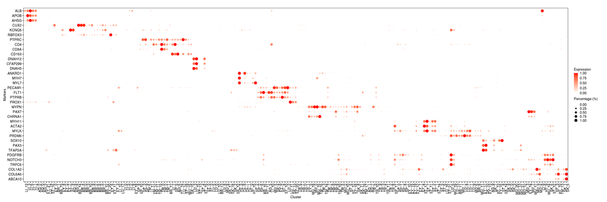

```r
flat_data <- melt(avg_exp_decontx_mat_subset_scaled2[markers, cluster_meta2$Cluster],
                  varnames = c("Markers", "Cluster"),
                  value.name = "Expression")

ggplot(flat_data, aes(x=Cluster, y=Markers, color=Expression, size=Expression)) +
  geom_point(stroke=0) + theme(axis.text.x = element_text(angle=90, hjust=1)) +
  scale_size(range = c(0, 5)) +  # Adjust dot size range +
  scale_y_discrete(limits = rev(unique(flat_data$Markers))) +  # Reverse marker order
  #scale_color_gradientn(colors = cmap_rna) +
  labs(x = "Cluster", y = "Markers", size = "Percentage (%)", color = "Expression") +
  scale_color_gradient(low = "white", high = "red")
```

```r
# pdf(paste0(figout, "/manual_marker_dotplot.pdf"), width=30, height=5)
# print(p)
# dev.off()
#
# png(paste0(figout, "/manual_marker_dotplot.png"), width=30, height=5, units ="in", res=300)
# print(p)
# dev.off()
```